# Tracking my protein over time

## Introduction

Over the past few weeks, I tracked the meals I ate, with a focus on understanding my protein intake. I recorded the timestamp of each meal, whether it was sweet or savoury, if it was self-cooked or not, and how many servings of fruits and vegetables were included. I also calculated the grams of protein in each meal.

This story aims to explore:

Whether cooking my meals led to a higher protein intake.

Whether savoury or sweet meals tended to be higher in protein.

How my protein consumption changed over time.

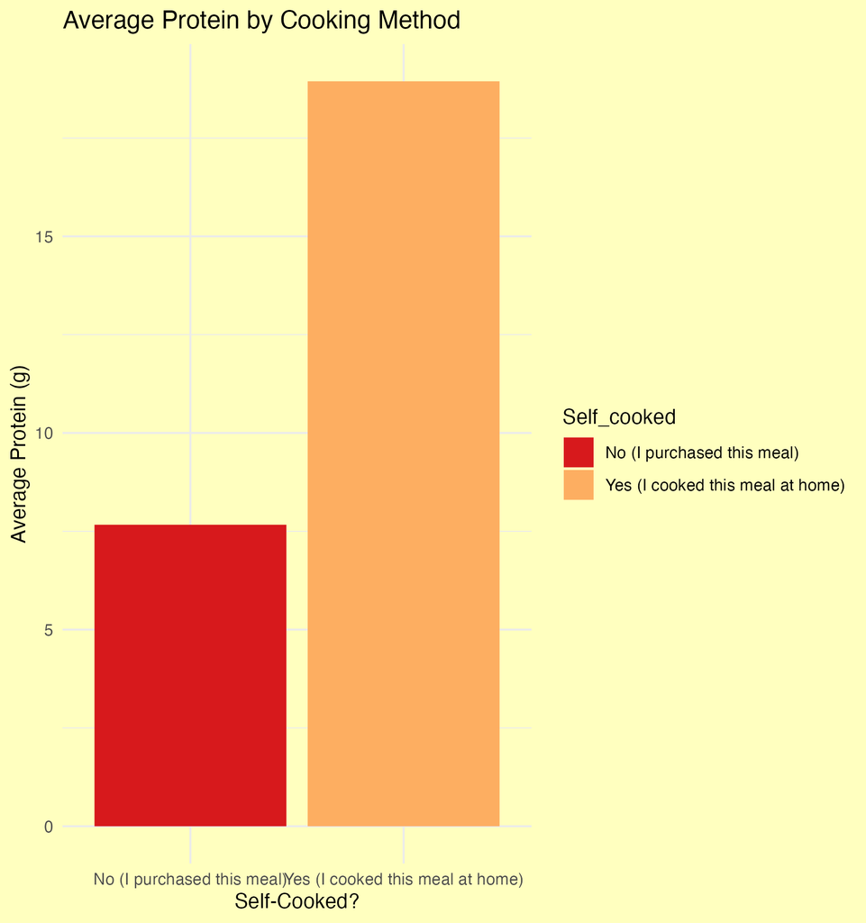

Average Protein by Cooking Method

This bar plot shows that meals cooked by me were more likely to include higher amounts of protein. In contrast, meals I didn’t cook tended to have a lower protein content. Cooking at home helped improve the nutritional quality of my meals.

## Plot 2

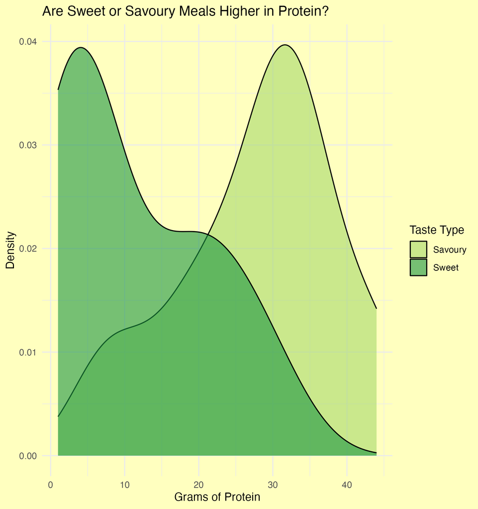

Are Sweet or Savoury Meals Higher in Protein?

This density plot compares the protein content of sweet versus savoury meals. Savoury meals had a noticeably higher average protein level, while sweet meals clustered around the lower end of the protein scale. This shows that sweet meals were generally less nutritious in terms of protein.

## Plot 3

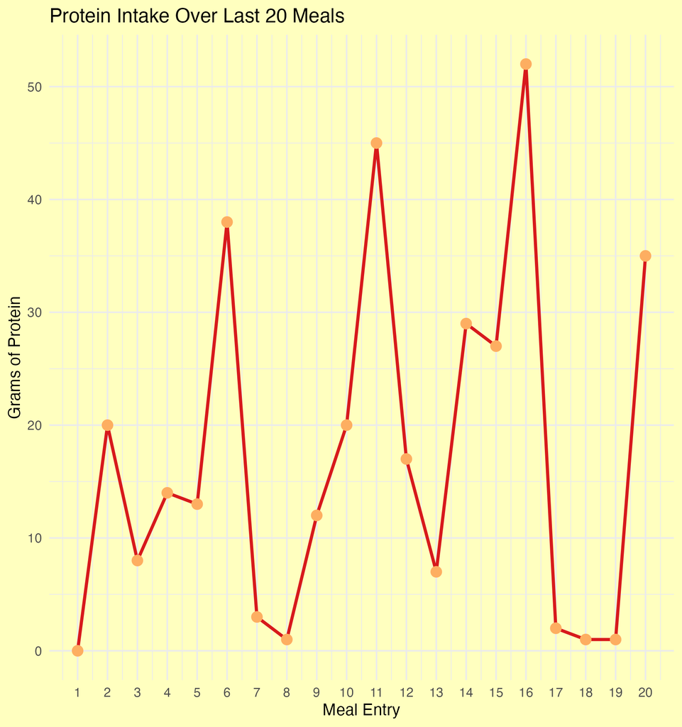

Protein Consumption Over Time

## Summary

From this analysis, I learned that:

Savoury meals are higher in protein than sweet ones.

Tracking my meals helped me make more intentional food choices, and I’m excited to continue using this awareness to guide healthier habits. In particular I will have more savoury meals, and continue to prepare most of my meals at home.